# PCA

Doynikov A.

March 30, 2023

В практической деятельности часто встречется ситуация, когда исходные данные существенно многомерны, но компоненты между собой достаточно сильно коррелированы. Итак есть многомерные наблюдения

$$\begin{equation*}y_t=
\left[\begin{matrix}y_{1,t}\\...\\y_{p,t}\end{matrix}
\right] \end{equation*}$$

Нашей задачей является возможность представленя каждого из наблюдений в виде вектора $Z_{t}$ некоторых вспомогательных переменных $z_{1,t},...,z_{q,t}$ в количестве $q$, которое значительно меньше исходного числа переменных $q<<p$. При этом эти новые переменные могут выбираться как из исходных, так и определяться по какому-либо правилу. Например каждая новая переменная $z_{i,t}$ есть линейная комбинация исходных. Формально эту задачу можно записать следующим образом. Пусть $Z=Z(x)$ есть $p$-мерная векторная функция исходных переменных $x_1,...,x_p$ со значением в $q$-мерном пространстве $(q<<p)$. Кроме того задана некоторая мера информативности $I_{q}(Z(X))$.

Конкретный выбор меры информативности зависит от специфики решаемой задачи и обычно нацелен на максимальное сохранений вполне определенной информации, которую несли в себе исходные данные. Обозначим через $F$ - класс всех допустимых преобразований исходных переменных. Задача заключается в определении такого набора признаков $Z$, что

$$I_{q}(Z(X))=max_{Z∈F}I_{q}(Z(X))$$
Различные варианты конкретизации данной постановки задачи приводят к каждому конкретному методу снижения размерности. Мы в дальнейшем рассмотрим только один из них.

## Метод главных компонент

Пусть $F$ - всевозможные линейные ортогональные нормированные комбинации исходных переменных.

$$z_{i}(X)=c_{i,1}(x_1-μ_1)+...+c_{i,p}(x_p-μ_{p})$$

$$\sum_{k=1}^{p}c_{i_k}^2=1$$

$$\sum_{k=1}^{p}c_{i_k}с_{j_k}=0,\mspace{25mu}i,j=1,2,...,p$$

$$I_{q}(Z(X))=\frac{Dz_1+...+Dz_{q}}{Dx_1+...+Dx_{p}}$$

Без ограничения общности будем в дальнейшем считать, что вектор средних $μ=(μ_1,...,μ_{p})=0$. Тогда при любом фиксированном $q<<p$ вектор искомых переменных z_1,…,z_{q} определяется как линейная комбинация исходных переменных $Z=LX$, где
$$\begin{equation*}L=
\left[\begin{matrix}l_{1,1}&l_{1,2}...l_{1,p}\\...\\l_{q,1}&l_{q,2}...l_{q,p}\end{matrix}
\right] \end{equation*}$$
где строки матрицы L удовлетворяют условиям ортогональности и такие, что

$$I_{q}(Z(X))=\max_{Z∈F}I_{q}(Z(X))$$
Определение. Первой главной компонентой $Z_1(X)$ называется такая нормированная линейная комбинация исходных переменных, которая среди всех прочих нормированных, центрированных линейных комбинаций имеет наибольшую дисперсию.

$k$-ой главной компонентой $Z_k(X)$ называется такая нормированная линейная комбинация исходных переменных, которая:

- Не коррелирует с предыдущими $k-1$.
- Имеет наибольшую дисперсию.

Для нахождения первой главной компоненты имеем следующую постановку задачи

$$D(l_1X)→\max$$
$$l_1l_1'=1$$
где $l_1$- первая строка матрицы $L$. Так как
$$D(l_1X) = E(l_1X)^2 = E(l_1XX′l_1 )=l\Sigma
l′$$

Тогда задачу нахождения певрй компоненты можно переписать

$$l_1\Sigma l_1'->\max$$
$$l_1l_1′=1$$
Введем функцию Лагранжа вида

$$\phi(l_1,\lambda)=l_1\Sigma
l_1′-\lambda(l_1l_1′-1)$$

Дифференцируя ее по компонентам вектора $l_1′$

$$((∂\phi(l_1,\lambda))/(∂l_1^1))=2\Sigma
l_1′-2\lambda l_1′$$

Приравнивая к нулю, получим систему линенйных алгебраических уравнений
$$(\Sigma-\lambda)l_1′=0$$
Последнее уравнение называется характеристичским. Матрица $\Sigma$-матрица ковариаций, поэтому является симметричной и положительно определенной. Следовательно система уравнений $p$ вещественных и неотрицательных корней
$$\lambda_1≥\lambda₂≥...≥\lambda_{p}≥0$$
которые по определению называются собственными значениями. Так как

$$Dz^1=D(l_1X)=(l_1XX′l_1′)=l_1\Sigma l_
1′$$

и

[output not shown]

То для максимизации величины дисперсии достаточно выбрать из $p$ собственных значений максимальное $\lambda_1$.

Аналогично можно показать, что

$$z_{k}(x)=l_{k}X$$

где $l_{k}-k$-ый собственный вектор, отвечающий $k$-ому по величине собственному значению.

### Свойства главных компонент

$$E(Z)=E(LX)=LE(X)=0$$

$$\Sigma_{z}=E(ZZ′)=E(LX)(LX)′=E(LXX′L′)=LE(XX′)L′=L\Sigma_{X}L′$$

Рассмотрим соотношение

$$(\Sigma-\lambda_{k}I)l_{k}′=0$$

Умножим его слева на $l_{j}$

$$l_{j}(\Sigma-\lambda_{k}I)l_{k}′=l_{j}\Sigma
l_{k}′-\lambda_{k}l_{j}l_{k}′=0$$

$$Dz_k=\lambda_{k}$$

Следствие

$$I_{q}(Z(X))=\frac{\lambda_1+...+\lambda_{q}}{\lambda_1+...+\lambda_{p}}$$

Метод очеь чувствителен к расбросу данных по абсолютной величине, поэтому рекомендуется нормировать исходные данные. Обычно применяют такие нормировки: * Приводят к нулевым средним и одинаковой единичной дисперсии

$$\frac{x_i-E[x_i]}{\sqrt{D[x_i]}},\mspace{25mu}i=1,2,...,p$$
* Неотрицательные данные приводят к величинам данных в интервале (0,1)

$$\frac{x_i}{\max x_i
},\mspace{25mu}i=1,2,...,p$$
* В финансовых данных обычно переходят к доходностям

$$r_{t,i}=
\frac{S_{t,i}}{S_{t-1,i}}-1\mspace{25mu}i=1,2,...,p; t =
1,...,T$$
$

### Пример с российскими акциями

Акции российских компаний торгуемые на российском рынке достаточно сильно коррелируют друг с другом. Посмотрим насколько сможем уменьшить размерность пространства и сколько информации о дисперсии рынка мы при этом сохраним. Читаем файл с данными.

```r
data <- read.csv("./micexmarket1.csv",header = TRUE)
head(data)
```

```
##   ï..239x12   GAZP  GMK LKOH   ROSN  RTKM   SBER   SNGZ     VTB RUSGIDRO PLZL
## 1  03/10/17 128.78 8855 3028 315.00 74.90 157.50 28.200 0.06505   0.9335 4450
## 2  03/13/17 129.93 8965 3051 318.25 76.41 158.92 28.350 0.06526   0.9321 4450
## 3  03/14/17 128.80 9097 3080 315.40 77.06 157.42 28.655 0.06506   0.9400 4455
## 4  03/15/17 127.60 9057 3088 314.70 76.64 156.20 28.435 0.06514   0.9400 4476
## 5  03/16/17 128.05 9054 3095 313.95 76.20 158.35 28.650 0.06550   0.9525 4400
## 6  03/17/17 128.94 9169 3130 314.45 75.00 161.15 28.935 0.06625   0.9580 4447
##       RTS    Rubl
## 1 1055.93 58.6750
## 2 1069.14 58.9925
## 3 1063.69 59.5325
## 4 1062.61 59.1450
## 5 1096.29 57.9000
## 6 1111.89 57.6350
```

Перейдем к доходностям в данных без колонки с датой

```r
(ncol <- dim(data)[2])
```

```
## [1] 13
```

```r
(nrow <- dim(data)[1])
```

```
## [1] 240
```

```r
stocks <- data[,2:ncol]
rates <- stocks[2:nrow,] / stocks [1:(nrow-1),] - 1
head(rates)
```

```
##           GAZP           GMK         LKOH         ROSN         RTKM
## 2  0.008929958  0.0124223602  0.007595773  0.010317460  0.020160214
## 3 -0.008696991  0.0147239264  0.009505080 -0.008955224  0.008506740
## 4 -0.009316770 -0.0043970540  0.002597403 -0.002219404 -0.005450298
## 5  0.003526646 -0.0003312355  0.002266839 -0.002383222 -0.005741127
## 6  0.006950410  0.0127015684  0.011308562  0.001592610 -0.015748031
## 7 -0.001163332 -0.0172319773 -0.011980831 -0.010494514  0.043333333
##           SBER         SNGZ          VTB     RUSGIDRO         PLZL          RTS
## 2  0.009015873  0.005319149  0.003228286 -0.001499732  0.000000000  0.012510299
## 3 -0.009438711  0.010758377 -0.003064664  0.008475485  0.001123596 -0.005097555
## 4 -0.007749968 -0.007677543  0.001229634  0.000000000  0.004713805 -0.001015333
## 5  0.013764405  0.007561104  0.005526558  0.013297872 -0.016979446  0.031695542
## 6  0.017682349  0.009947644  0.011450382  0.005774278  0.010681818  0.014229811
## 7  0.016444307  0.018489718  0.014339623  0.015866388 -0.008320216  0.008553004
##           Rubl
## 2  0.005411163
## 3  0.009153706
## 4 -0.006509050
## 5 -0.021049962
## 6 -0.004576857
## 7 -0.003123102
```

```r
tail(rates)
```

```
##             GAZP           GMK         LKOH         ROSN         RTKM
## 235 -0.021374686  1.254593e-03 -0.005957898 -0.021180030 -0.003518546
## 236 -0.010920771  6.712611e-03 -0.001198721 -0.012364760 -0.004560836
## 237  0.021866205 -4.356330e-03 -0.005200693  0.003129890  0.006503104
## 238 -0.007132768 -3.393160e-03  0.003753351 -0.005616225  0.001615272
## 239 -0.014439149 -8.959771e-05 -0.006143162 -0.011609664 -0.005864243
## 240  0.000000000  0.000000e+00  0.000000000  0.000000000  0.000000000
##              SBER          SNGZ           VTB     RUSGIDRO         PLZL
## 235  0.0095447871 -0.0067908758 -0.0049279757  0.003582853  0.012914335
## 236 -0.0072727273 -0.0105189341 -0.0017142857 -0.006502614  0.011474713
## 237  0.0146520147  0.0150602410  0.0009540164  0.013860370 -0.010924370
## 238 -0.0107220217 -0.0006982021  0.0102935570 -0.005949367 -0.001062022
## 239 -0.0001094771 -0.0113537118  0.0320754717 -0.020756399 -0.005528386
## 240  0.0000000000  0.0000000000  0.0000000000  0.000000000  0.000000000
##              RTS         Rubl
## 235 -0.008782780  0.014745189
## 236 -0.009849472  0.006146012
## 237  0.014172142 -0.002748811
## 238  0.001500574 -0.011200560
## 239 -0.008787058  0.006017699
## 240  0.000000000  0.000000000
```

Последнюю строку из нулей уберем

```r
rates <- rates[1:(nrow-2),]
tail(rates)
```

```
##             GAZP           GMK         LKOH         ROSN         RTKM
## 234 -0.022798635 -3.385281e-02 -0.016152143 -0.020740741  0.007533235
## 235 -0.021374686  1.254593e-03 -0.005957898 -0.021180030 -0.003518546
## 236 -0.010920771  6.712611e-03 -0.001198721 -0.012364760 -0.004560836
## 237  0.021866205 -4.356330e-03 -0.005200693  0.003129890  0.006503104
## 238 -0.007132768 -3.393160e-03  0.003753351 -0.005616225  0.001615272
## 239 -0.014439149 -8.959771e-05 -0.006143162 -0.011609664 -0.005864243
##              SBER          SNGZ           VTB     RUSGIDRO         PLZL
## 234 -0.0208835053 -0.0142464813 -0.0193308550 -0.016610042  0.021547933
## 235  0.0095447871 -0.0067908758 -0.0049279757  0.003582853  0.012914335
## 236 -0.0072727273 -0.0105189341 -0.0017142857 -0.006502614  0.011474713
## 237  0.0146520147  0.0150602410  0.0009540164  0.013860370 -0.010924370
## 238 -0.0107220217 -0.0006982021  0.0102935570 -0.005949367 -0.001062022
## 239 -0.0001094771 -0.0113537118  0.0320754717 -0.020756399 -0.005528386
##              RTS         Rubl
## 234 -0.019354002  0.001606282
## 235 -0.008782780  0.014745189
## 236 -0.009849472  0.006146012
## 237  0.014172142 -0.002748811
## 238  0.001500574 -0.011200560
## 239 -0.008787058  0.006017699
```

Выполняем метод главных компонент

```r
    pca <- prcomp(rates, scale = TRUE)
    summary(pca)
```

```
## Importance of components:
##                           PC1    PC2     PC3     PC4     PC5     PC6     PC7
## Standard deviation     2.1196 1.1801 1.01642 0.96103 0.90316 0.84929 0.81820
## Proportion of Variance 0.3744 0.1160 0.08609 0.07697 0.06798 0.06011 0.05579
## Cumulative Proportion  0.3744 0.4905 0.57655 0.65351 0.72149 0.78159 0.83738
##                            PC8     PC9    PC10    PC11    PC12
## Standard deviation     0.75408 0.68270 0.66429 0.63598 0.26633
## Proportion of Variance 0.04739 0.03884 0.03677 0.03371 0.00591
## Cumulative Proportion  0.88477 0.92361 0.96038 0.99409 1.00000
```

Средние значения акций

```r
    pca$center
```

```
##          GAZP           GMK          LKOH          ROSN          RTKM
##  3.821489e-04  1.108769e-03  9.629733e-04  9.580048e-05 -3.564964e-04
##          SBER          SNGZ           VTB      RUSGIDRO          PLZL
##  2.444232e-03  1.540081e-04 -5.978541e-04 -6.559255e-04  3.186958e-04
##           RTS          Rubl
##  8.408165e-04 -1.119837e-04
```

Стандартныя отклонения,объясняюшие главными копонентами

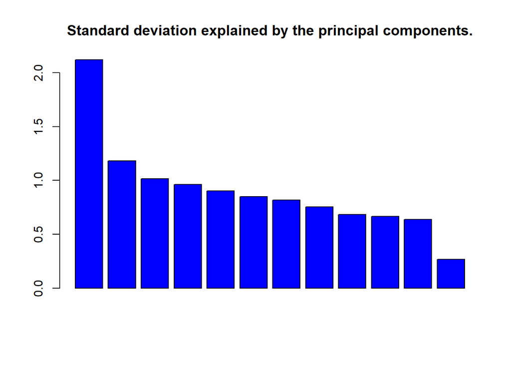

```r
      mp <- barplot(pca$sdev,main = "Standard deviation explained by the principal components.", col = "blue")
```

```r
      tot <- pca$sdev
      dim(pca$rotation)
```

```
## [1] 12 12
```

Важность каждой главной компоненты

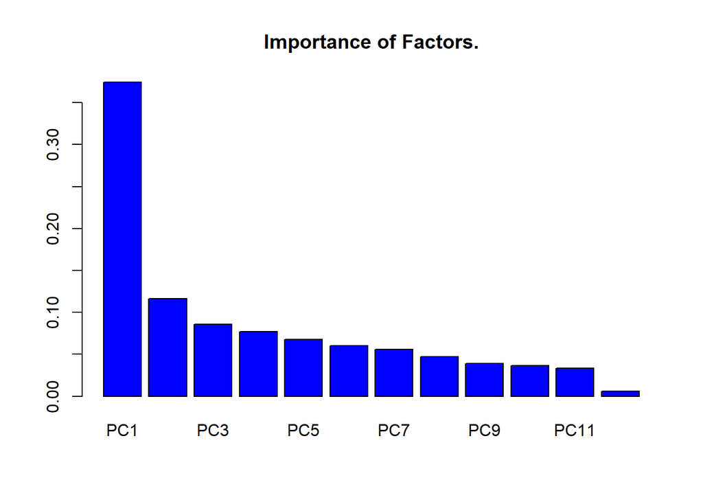

```r
ss <- summary(pca)
mp <- barplot(ss$importance[2,],main = "Importance of Factors.", col = "blue") # default
```

```r
tot <- ss$importance[2,]
```

Накопленная мера информативности

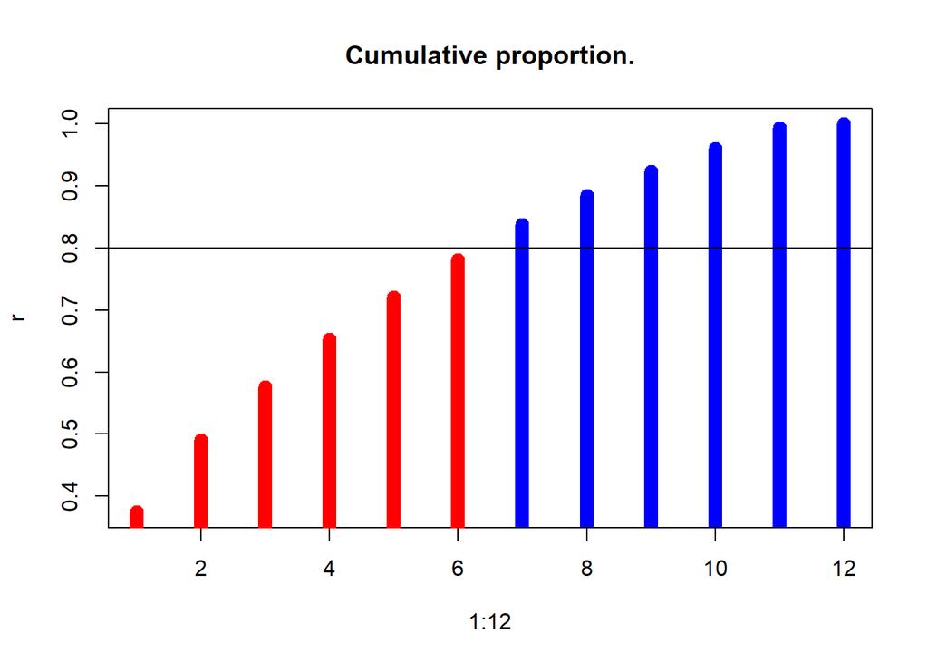

```r
 ss <- summary(pca)
his <- ss$importance[3,]
his[7:12]<- NA
r <- as.matrix(cbind(ss$importance[3,],his))

mp <- matplot(1:12,r,type = 'h',lty = 1, lwd = 10,main = "Cumulative proportion.", col = c("blue",'red')) # default
abline(h = 0.8,col = 'black')
```

```r
tot <- ss$importance[2,]
```

Функция для вычисления факторов

```r
scores <- function(ldata,pca,number)
{
  cdata <- ldata
  m <- dim(ldata)[2]
  for (i in 1:m)
    cdata[,i] <- ldata[,i] - pca$center[i]
  loads <- pca$rotation[,1:number]
  cdata <- as.matrix(cdata)
  f <- cdata %*% loads
  return (f)
}
```

Вычисляем факторы
$$F=(R-E[R])L$$

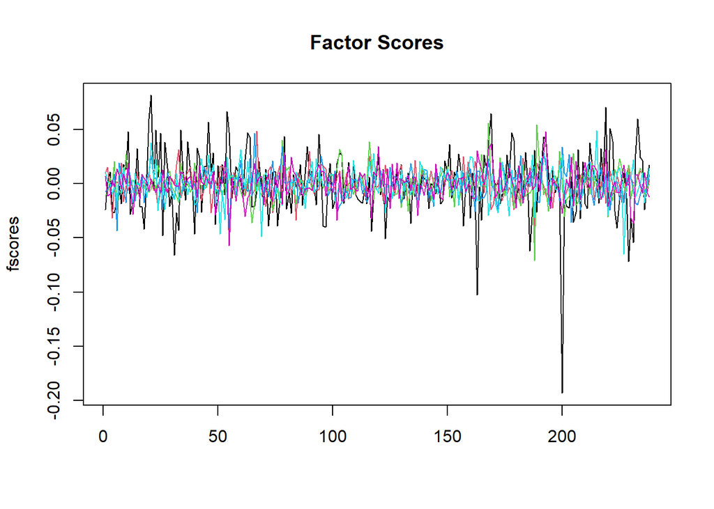

```r
number <- 6
fscores <- scores(rates,pca,number)
matplot(fscores,type = 'l',lty = 1, col = 1:number,main = 'Factor Scores')
```

### Восстанавливаем данные по факторам и нагрузкам

Восстанавливаем данные по факторам и нагрузкам
$$\hat R=FL'+E[R]$$

```r
restoreData<- function(fscores,loadings,center)
{
  npca <- dim(fscores)[2]
  myeigen <- t(loadings[,1:npca])
  rest <- fscores %*%myeigen
  m <- length(center)
  if (m == dim(rest)[2])
  {
    for (i in 1:m)
    rest[,i] <- rest[,i]+center[i]
  }
  return(rest)
}
rest <- restoreData(fscores,pca$rotation,pca$center)
head(rest)
```

```
##            GAZP           GMK         LKOH          ROSN         RTKM
## 2  0.0095985639  0.0135903521  0.007973375  8.057092e-03  0.020070842
## 3 -0.0003269295  0.0063417349  0.001286545 -4.052802e-06  0.009056668
## 4 -0.0064859206 -0.0001081263 -0.003570599 -3.164065e-03 -0.007735004
## 5  0.0076674367 -0.0044016781  0.006886630  8.683745e-03 -0.003223310
## 6  0.0085586261  0.0092065613  0.011212236  1.065418e-02 -0.014472422
## 7  0.0073149869 -0.0142364337 -0.007697254 -3.604467e-03  0.043731136
##           SBER         SNGZ           VTB     RUSGIDRO          PLZL
## 2  0.010544548  0.006964391  0.0048744337 -0.001669707 -0.0005922712
## 3 -0.007525997  0.001544464  0.0059980113  0.004069796  0.0015522007
## 4 -0.004250392 -0.007522415  0.0001344572  0.002906656  0.0016927884
## 5  0.014235720  0.001913823  0.0018187215  0.013754100 -0.0132200416
## 6  0.014887065  0.006995794  0.0088021055  0.004871393  0.0133402256
## 7  0.009519807  0.013392172 -0.0030477864  0.021747211 -0.0035558026
##            RTS         Rubl
## 2  0.008840221  0.002982153
## 3 -0.006552143  0.011681989
## 4 -0.002479645 -0.004471096
## 5  0.020786014 -0.025314250
## 6  0.013145407 -0.004998156
## 7  0.007186519 -0.003559153
```

[figure not shown]

```r
r <- unlist(rates[1,])
matplot(cbind(rest[1,],r),type ='b',pch=21,lwd = 2,main = 'Restored rates',col = c('blue','green'),lty = 1)
legend('topleft',c('original rates','restored'),lty=1,lwd=2,col=c('blue','green') )
```

## Daily Treasury Yield Curve Rates

Особенно интересное применение PCA к кривым доходностей государственных и корпоротивных облигаций. Кривой доходностей или временная структура доходностей или англ. Yield Curve Rates называют функцию доходности от времени истечения контракта. Время до истечения контракта меняется обычно от 0 до 30 лет
$$r(\tau ) ,\mspace{25mu} \tau=0...30
years$$
Данные публикуются соответствующими органами каждый день. В лекции данные получены с оффициалиьного правительственного сайта https://www.treasury.gov Считываем данные

```r
library(xts)
tr_rates <- read.csv("./rates.csv",header = TRUE )
head(tr_rates)
```

```
##    ï..Date X1.Mo X2.Mo X3.Mo X6.Mo X1.Yr X2.Yr X3.Yr X5.Yr X7.Yr X10.Yr X20.Yr
## 1 01/03/22  0.05  0.06  0.08  0.22  0.40  0.78  1.04  1.37  1.55   1.63   2.05
## 2 01/04/22  0.06  0.05  0.08  0.22  0.38  0.77  1.02  1.37  1.57   1.66   2.10
## 3 01/05/22  0.05  0.06  0.09  0.22  0.41  0.83  1.10  1.43  1.62   1.71   2.12
## 4 01/06/22  0.04  0.05  0.10  0.23  0.45  0.88  1.15  1.47  1.66   1.73   2.12
## 5 01/07/22  0.05  0.05  0.10  0.24  0.43  0.87  1.17  1.50  1.69   1.76   2.15
## 6 01/10/22  0.05  0.06  0.13  0.28  0.46  0.92  1.21  1.53  1.71   1.78   2.15
```

```r
(ndays  <-  dim(tr_rates)[1])
```

```
## [1] 310
```

```r
(ncol  <-  dim(tr_rates)[2])
```

```
## [1] 12
```

Посмотрим на кривую доходностей последнего дня наблюдений

```r
 (last <- tr_rates[ndays,2:ncol])
```

```
##     X1.Mo X2.Mo X3.Mo X6.Mo X1.Yr X2.Yr X3.Yr X5.Yr X7.Yr X10.Yr X20.Yr
## 310  4.74  4.77  4.97  4.92  4.63   4.1  3.87  3.66  3.61   3.55   3.88
```

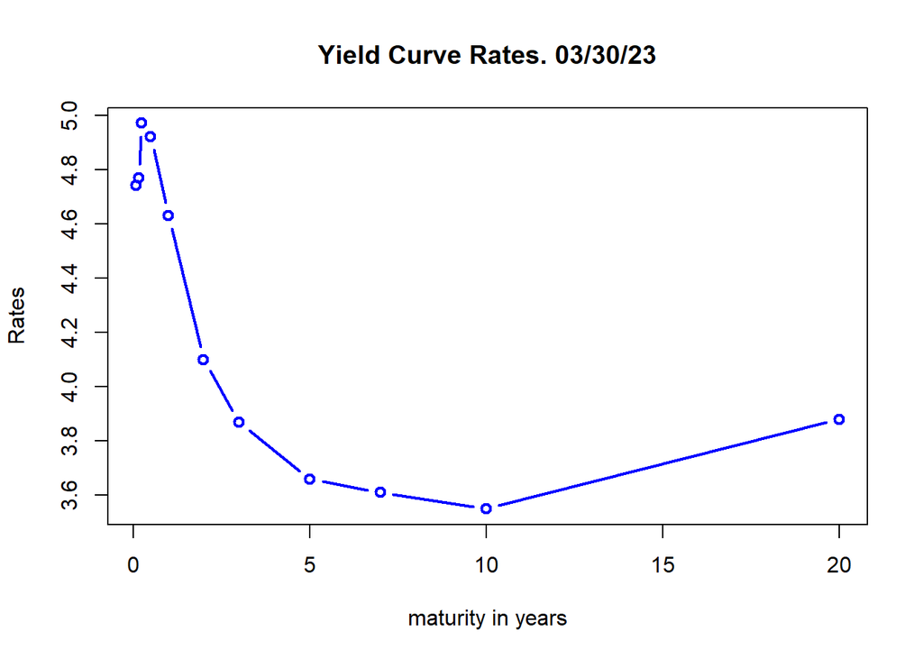

```r
 lastdate <- tr_rates[ndays,1]
 maturity <- c(1/12,2/12,0.25,0.5,1,2,3,5,7,10,20)
 plot(maturity,last,type = 'b',pch = 21,main =paste("Yield Curve Rates.",lastdate),col = 'blue',lwd = 2,ylab= "Rates",xlab = "maturity in years")
```

Зададим тип объекта как `xts` - временные ряды для считаных доходностей

```r
  tr_dates <- as.Date(tr_rates[,1],"%m/%d/%y")
head(tr_dates)
```

```
## [1] "2022-01-03" "2022-01-04" "2022-01-05" "2022-01-06" "2022-01-07"
## [6] "2022-01-10"
```

```r
  rates.xts <- as.xts(tr_rates[2:ncol], order.by = tr_dates)
  head(rates.xts)
```

```
##            X1.Mo X2.Mo X3.Mo X6.Mo X1.Yr X2.Yr X3.Yr X5.Yr X7.Yr X10.Yr X20.Yr
## 2022-01-03  0.05  0.06  0.08  0.22  0.40  0.78  1.04  1.37  1.55   1.63   2.05
## 2022-01-04  0.06  0.05  0.08  0.22  0.38  0.77  1.02  1.37  1.57   1.66   2.10
## 2022-01-05  0.05  0.06  0.09  0.22  0.41  0.83  1.10  1.43  1.62   1.71   2.12
## 2022-01-06  0.04  0.05  0.10  0.23  0.45  0.88  1.15  1.47  1.66   1.73   2.12
## 2022-01-07  0.05  0.05  0.10  0.24  0.43  0.87  1.17  1.50  1.69   1.76   2.15
## 2022-01-10  0.05  0.06  0.13  0.28  0.46  0.92  1.21  1.53  1.71   1.78   2.15
```

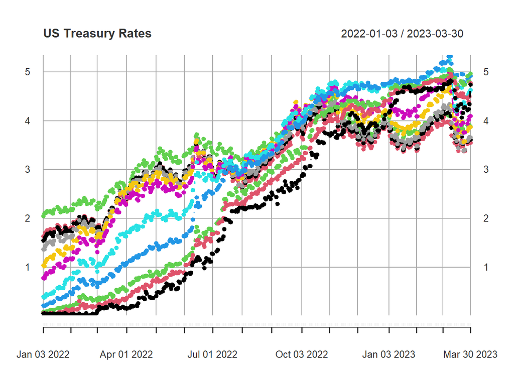

```r
  plot(rates.xts,type = 'b',pch =20,main = "US Treasury Rates")
```

Проводим PCA

```r
    pca <- prcomp(rates.xts, scale = FALSE)
    summary(pca)
```

```
## Importance of components:
##                          PC1     PC2     PC3     PC4     PC5     PC6     PC7
## Standard deviation     4.219 0.77959 0.17049 0.13189 0.06922 0.05065 0.04319
## Proportion of Variance 0.964 0.03292 0.00157 0.00094 0.00026 0.00014 0.00010
## Cumulative Proportion  0.964 0.99688 0.99845 0.99940 0.99965 0.99979 0.99989
##                            PC8     PC9    PC10     PC11
## Standard deviation     0.03433 0.02379 0.01206 0.007176
## Proportion of Variance 0.00006 0.00003 0.00001 0.000000
## Cumulative Proportion  0.99996 0.99999 1.00000 1.000000
```

Посмотрим на накопленную меру информативности

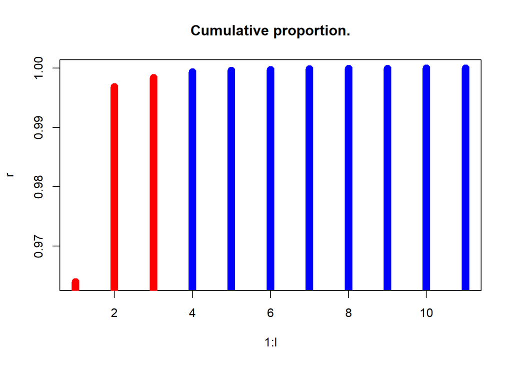

```r
 ss <- summary(pca)
 his <- ss$importance[3,]
 l <- length(his)
 his[4:l]<- NA
 r <- as.matrix(cbind(ss$importance[3,],his))

mp <- matplot(1:l,r,type = 'h',lty = 1, lwd = 10,main = "Cumulative proportion.", col = c("blue",'red')) # default
abline(h = 0.8,col = 'black')
```

Только в первых трех значениях информативности есть изменения, а начиная с 4-ой мера информативности практически не изменяется, имея значения около 100%. В силу этого первые три фактора среди участников рынка получили название **shift**,**twist**,**butterfly**. В интернете легко найти огромное количество статей для участников рынка облигаций и исследователей, где те или иные изменения доходностей объясняют изменением в динамике **shift**,**twist**,**butterfly** и политическими или экономическими событиями их вызвавшими.Достаточно в строке поиска написать **shift**,**twist**,**butterfly** и сразу наткнемся например на это https://papers.ssrn.com/sol3/papers.cfm?abstract_id=1601518

```r
tot <- ss$importance[2,]
rownames(ss$rotation)
```

```
##  [1] "X1.Mo"  "X2.Mo"  "X3.Mo"  "X6.Mo"  "X1.Yr"  "X2.Yr"  "X3.Yr"  "X5.Yr"
##  [9] "X7.Yr"  "X10.Yr" "X20.Yr"
```

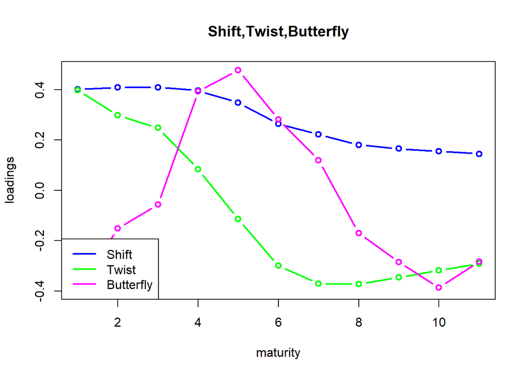

```r
matplot(cbind(ss$rotation[,1],ss$rotation[,2],ss$rotation[,3]),type = 'b',pch=21,lwd = 2,
     col = c("blue","green","magenta"),main= "Shift,Twist,Butterfly",ylab = "loadings",xlab="maturity",lty=1 )
legend("bottomleft",c("Shift","Twist","Butterfly"),lty=c(1,1,1),lwd = 2,col = c("blue","green","magenta"))
```

### Факторы доходностей

Вычислим три главных фактора **shift**,**twist**,**butterfly**.
$$F=(R-E[R])L$$

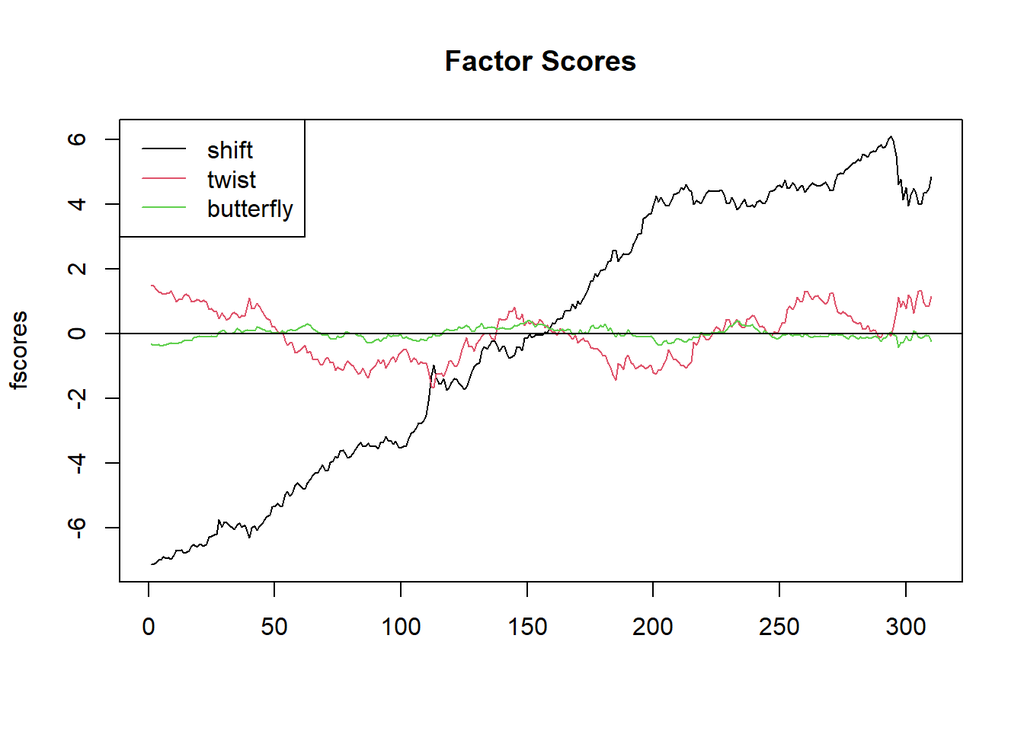

```r
number <- 3
fscores <- scores(rates.xts,ss,number)
matplot(fscores,type = 'l',lty = 1, col = 1:number,main = 'Factor Scores')
legend('topleft',c('shift','twist','butterfly'),col = 1:number,lty = 1)
abline(h=0)
```

Проверим выполнение свойств полученных факторов. Во-первых должно выполняться, что $E[f] = 0$. Действительно

```r
  means <- c(mean(fscores[,1]),mean(fscores[,2]),mean(fscores[,3]))
  means
```

```
## [1] -1.564609e-17 -2.449604e-16  7.401748e-17
```

Во-вторых факторы должны быть некоррелированы

```r
  fscores <- as.matrix(fscores)
  cor(fscores)
```

```
##               PC1           PC2           PC3
## PC1  1.000000e+00 -9.630475e-15 -4.559154e-15
## PC2 -9.630475e-15  1.000000e+00  9.837542e-15
## PC3 -4.559154e-15  9.837542e-15  1.000000e+00
```

### Востановленные доходности

Восстаномим доходности по факторам и сравним оригинальные и восстановленные доходности последнего дня

$$\hat R=FL'+E[R]$$

```r
rest <- restoreData(fscores,ss$rotation,ss$center)
ndays <- dim(fscores)[1]
head(rest)
```

```
##                 X1.Mo      X2.Mo      X3.Mo     X6.Mo     X1.Yr     X2.Yr
## 2022-01-03 0.09281967 0.03534993 0.08883291 0.1714099 0.3880640 0.8377427
## 2022-01-04 0.10570124 0.03797273 0.08773132 0.1512047 0.3672076 0.8294984
## 2022-01-05 0.09561869 0.03780840 0.09257178 0.1701590 0.4038203 0.8814178
## 2022-01-06 0.07845606 0.03411087 0.09487208 0.1942753 0.4423290 0.9252150
## 2022-01-07 0.08999105 0.03872333 0.09723486 0.1827234 0.4334408 0.9298707
## 2022-01-10 0.09251427 0.05288529 0.11621095 0.2201584 0.4781292 0.9709202
##               X3.Yr    X5.Yr    X7.Yr   X10.Yr   X20.Yr
## 2022-01-03 1.075028 1.357428 1.531173 1.617441 2.029502
## 2022-01-04 1.075862 1.372352 1.551221 1.641899 2.048471
## 2022-01-05 1.133450 1.428900 1.604479 1.691849 2.093904
## 2022-01-06 1.176783 1.463714 1.633923 1.716289 2.117956
## 2022-01-07 1.190233 1.488997 1.662929 1.748419 2.144347
## 2022-01-10 1.226751 1.514558 1.683061 1.763735 2.160490
```

[figure not shown]

```r
r <- unlist(rates.xts[ndays,])
r <- as.matrix(r,ncol = 1)
r <- t(r)
s <- as.matrix(rest[ndays,],ncol = 1)
title <- paste('Restored rates.',' Date =',lastdate)
matplot(cbind(s,r),type ='b',pch=21,lwd = 2,main = title,col = c('blue','green'),lty = 1)
legend('topleft',c('original rates','restored'),lty=1,lwd=2,col=c('blue','green'))
```

### Непрерывное начисление (continuous compounding)

Предположим, что некоторое количество средств $A$ инвестируется на срок $n$ лет с ежегодной доходностью $R$. Тогда, если начисление дохода будет происходить один раз в год, то через $n$ лет мы вернем

$$A(1+R)^n$$

Если же начисление будет происходить $m$ раз в год, то в итоге мы получим
$$A(1+R/m)^{mn}$$

Предел последнего выражения при стремлении m к бесконечности и называют непрерывным начислением.

Таким образом при непрерывном начислении дохода через n лет мы вернем $Aexp(Rn)$.

C другой стороны, чтобы через $n$ лет получить $A$ сейчас нам надо вложить $Aexp(-Rn)$ под процент $R$.

## Цена бонда

```r
library(FinAna)
par <- 1000
tau <- 10
yield <-  0.08
m <- 2
coupon <- 0.09
bond.price(par,coupon,tau,yield,m)
```

```
## [1] 1067.952
```

## Цена портфеля облигаций

Пусть вектор $\beta=(\beta_{\tau_1},...,\beta_{\tau_k})$ - число облигаций c номиналом $N=(N_1,...,M_k)$ со сроками до погашения $\tau=(\tau_1,...\tau_k)$ (будем считать,что все $\tau_i$ совпадают со сроками до погашения в данных, в противном случай соответствующую доходность получают интерполяцией) и купонным доходом $С=(c_1,...,c_k)$ и числом купонных выплат в год $m=(m_1,...,m_r)$

Пусть функция $B(N,c,\tau,\gamma,m)$ - цена облигации номинала $N$,купоном $c$, сроком до истечения $\tau$, рыночной доходностью $\gamma$ и $m$ начислением купонного дохода в год, тогда
$$\Pi = \sum_{i=1}^k\beta_i
B(N_i,c_i,\tau_i,\gamma_i,m_i)$$
стоимость портфеля облигаций.

## What-If сценарии

Надежное управление рыночными рисками невозможно без понимания степени влияния той или иной характеристики рынка на портфель в целом. Один из приемов, который позволяет оценить возможные последствия этих изменений в теории риск-менеджмента носит название what-if сценарии. Само название **what-if** предполагает, что основной задачей здесь является поиск ответа на типичный вопрос “Что произойдет с портфелем, если характеристика рынка … изменится на … ?”. Разумеется, что без знания точных выражений для стоимости всех входящих в портфель финансовыхинструментов или их оценок по некоторой модели здесь не обойтись. В качестве характеристики, с которой проигрывается сценарий **what-if**, могут выступать как присутствующие на рынке или наблюдаемые всеми участниками рынка характеристики (учетная ставка, имплайд волатильность и т.д.), так и ненаблюдаемые характеристики, известные более узкому кругу исследователей и участников рынка (факторы PCA) последние обычно являются параметрами специально разработанных, зачастую закрытых от посторонних, моделей.

В настоящее время все более популярной становится факторная модель временных структур, дающая экономный способ их представления. Факторы не являются непосредственно наблюдаемыми на рынке величинами, но их изменения легко интерпретируются в терминах изменения временной структуры. Ранее в классической теории рассматривались только сценарии what-if соотвествующие однофакторной модели (параллельный сдвиг или shift)

Переход от однофакторной к трехфакторной модели позволяет строить уже и более сложные сценарии. Например,что произойдет с портфелем облигаций, если 2-й фактор (twist) увеличится на 10%? Или другой вопрос. Что произойдет с портфелем облигаций, если 3-фактор(butterfly) изменит знак на противоположный. Зная последние значения факторов рынка и формулы расчета цены портфеля такого рода сценарии легко реализовать